# Анализ и разработка стратегии взаимодействия сети фитнес центров с клиентами для их удержания.

## Построение моделей прогнозирования оттока клиентов

По условиям сформулированной задачи можно сказать, что она является типичным примером задач бинарной классификации с учителем. Для её решения подходят следующие алгоритмы: Логистическая регрессия, дерево принятия решений, случайный лес и градиентный бустинг. В данном проекте применим первый и третий (`Логистическая регрессия` и `Cлучайный лес`), а также проведем их оценку метриками:

- `Accuracy`, которая оценивает долю верных ответов среди всех ((TP+TN)/n), но дает погрешность если объекты соотносятся примерно поровну (в нашем случае это не так ведь целевые значения разделяются 25:75);
- `Precision` показывает какая доля прогнозов относительно 1 верна по сравнению с числом прогнозов 1 (TP/(TP+FP));
- `Recall` показывает сколько верных 1 по отношению ко всем 1 в итоге (TP/(TP+FN))

```python
df = df.copy()
```

```python
X = df.drop('Churn', axis = 1)
y = df['Churn']

# разделим модель на обучающую и валидационную выборку
X_train, X_test, y_train, y_test = train_test_split(X, y, test_size=0.2, random_state=0)

# зададим обучим модель стандартизации признаков
scaler = StandardScaler()
scaler.fit(X_train)

# Преобразем обучающий и валидационные наборы данных
X_train_st = scaler.transform(X_train)
X_test_st = scaler.transform(X_test)
# зададим список моделей
models = [
    LogisticRegression(solver='liblinear', random_state=0),
    RandomForestClassifier(random_state=0)
]

# напишем цикл, который выводит метрики по списку моделей
for i in models:
    print(i)
    make_prediction(i, X_train_st, y_train, X_test_st, y_test)
```

```
LogisticRegression(random_state=0, solver='liblinear')
Accuracy:0.91, Precision: 0.83, Recall: 0.85
RandomForestClassifier(random_state=0)
Accuracy:0.91, Precision: 0.83, Recall: 0.81
```

Итак, метрики показывают, что обе модели подходят для прогнозов (все показатели приближаются к 1), а на модели LogisticRegression Recall выше.

**Промежуточные выводы:**

1. Алгоритмы обучения (Логистическая регрессия и Случайный лес) с помощью метрик Accuracy, Precision и Recall показали приемлемую точность на валидационной выборке.
2. В соответствии с метрикой Recall алгоритм логистической регрессии оказался немного точнее.

к Содержанию

## Кластеризация клиентов

Разделим клиентов на 5 кластеров чтобы оценить какой из кластеров оказывает наибольшее влияние на отток клиентов.

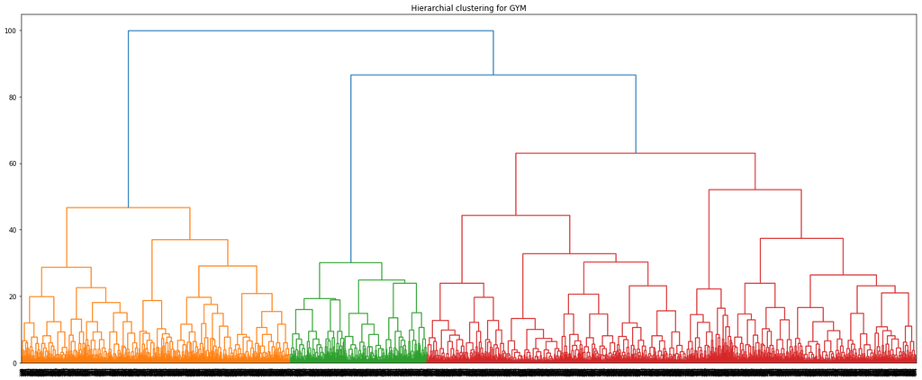

```python
# стандартизация данных перед работой с алгоритмами
sc = StandardScaler()
X_sc = sc.fit_transform(X)

linked = linkage(X_sc, method = 'ward')
plt.figure(figsize=(25, 10))
dendrogram(linked, orientation='top')
plt.title('Hierarchial clustering for GYM')
plt.show()
```